# Project_8

AZM

2022-10-04

```r
library(tidyverse)
library(openintro)
library(infer)
library(statsr)
data('hfi', package='openintro')
```

# Exercise 1

## What are the dimensions of the dataset?

```r
dim(hfi)
```

```
## [1] 1458  123
```

# Exercise 2

## What type of plot would you use to display the relationship between the personal freedom score, pf_score, and one of the other numerical variables? Plot this relationship using the variable pf_expression_control as the predictor. Does the relationship look linear? If you knew a country’s pf_expression_control, or its score out of 10, with 0 being the most, of political pressures and controls on media content, would you be comfortable using a linear model to predict the personal freedom score?

Looking at the scatterplot, I would say the relationship looks linear and thus a linear model can predict the personal freedom score.

```r
hfi %>%
  summarise(cor(pf_expression_control, pf_score, use = "complete.obs"))
```

| cor(pf_expression_control, pf_score, use = "complete.obs") |
| --- |
| 0.7963894 |

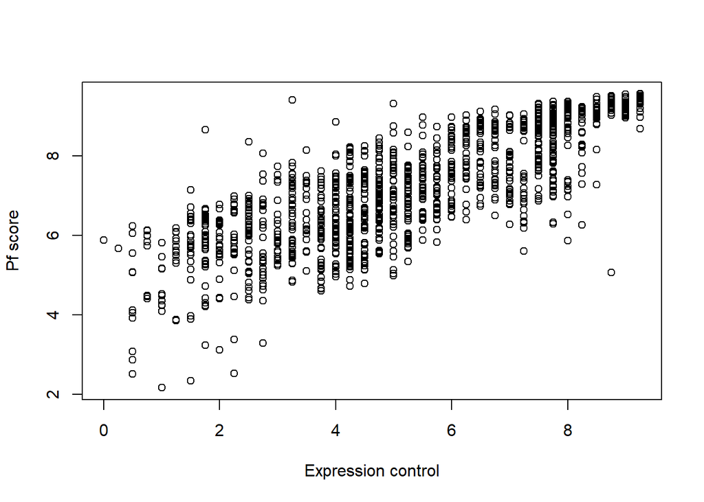

```r
plot(hfi$pf_score ~ hfi$pf_expression_control,
     xlab = "Expression control", ylab = "Pf score")
```

# Exercise 3

## Looking at your plot from the previous exercise, describe the relationship between these two variables. Make sure to discuss the form, direction, and strength of the relationship as well as any unusual observations.

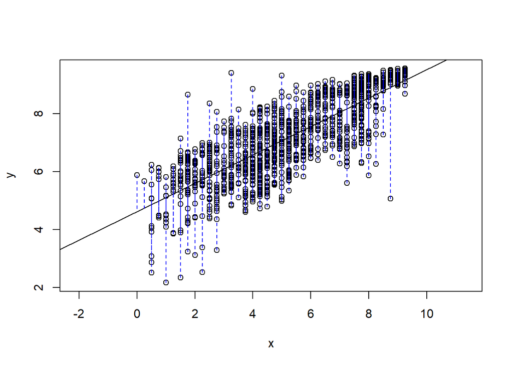

```
## Click two points to make a line.

## Call:
## lm(formula = y ~ x, data = pts)
##
## Coefficients:
## (Intercept)            x
##      4.6171       0.4914
##
## Sum of Squares:  952.153
```

```r
hfi1 <- hfi[c("pf_score", "pf_expression_control")] %>%
   filter(!is.na(pf_expression_control)|!is.na(pf_score))

# Drop NAs
hfi1 <- drop_na(hfi1)
row.names <- NULL
DATA606::plot_ss(x = hfi1$pf_expression_control, y = hfi1$pf_score)
```

Practically, there are some massive outliers, but for the most part it appears to be a positive linear relationship. The strength appears to be high, as they are very tightly correlated.

# Exercise 4

## Using plot_ss, choose a line that does a good job of minimizing the sum of squares. Run the function several times. What was the smallest sum of squares that you got? How does it compare to your neighbors?

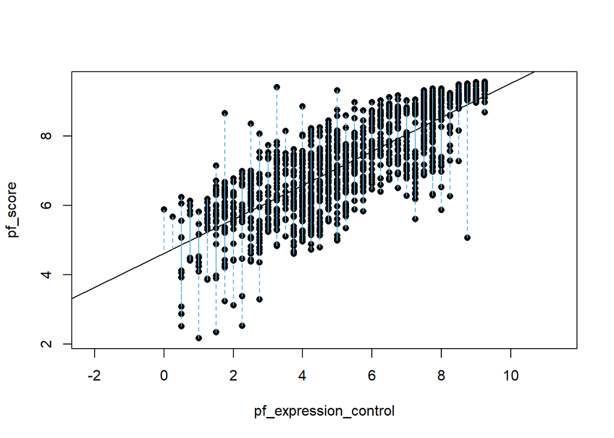

```
## Click two points to make a line.

## Call:
## lm(formula = y ~ x, data = pts)
##
## Coefficients:
## (Intercept)            x
##      4.6171       0.4914
##
## Sum of Squares:  952.153
```

```r
plot_ss(x = pf_expression_control, y = pf_score, data = hfi1)
```

The Smallest sum of square I received was 952!

# Exercise 5

## Fit a new model that uses pf_expression_control to predict hf_score, or the total human freedom score. Using the estimates from the R output, write the equation of the regression line. What does the slope tell us in the context of the relationship between human freedom and the amount of political pressure on media content?

```r
reverse <- lm(hf_score ~ pf_expression_control, data = hfi)
summary(reverse)
```

```
##
## Call:
## lm(formula = hf_score ~ pf_expression_control, data = hfi)
##
## Residuals:
##     Min      1Q  Median      3Q     Max
## -2.6198 -0.4908  0.1031  0.4703  2.2933
##
## Coefficients:
##                       Estimate Std. Error t value Pr(>|t|)
## (Intercept)           5.153687   0.046070  111.87   <2e-16 ***
## pf_expression_control 0.349862   0.008067   43.37   <2e-16 ***
## ---
## Signif. codes:  0 '***' 0.001 '**' 0.01 '*' 0.05 '.' 0.1 ' ' 1
##
## Residual standard error: 0.667 on 1376 degrees of freedom
##   (80 observations deleted due to missingness)
## Multiple R-squared:  0.5775, Adjusted R-squared:  0.5772
## F-statistic:  1881 on 1 and 1376 DF,  p-value: < 2.2e-16
```

# Exercise 6

## If someone saw the least squares regression line and not the actual data, how would they predict a country’s personal freedom school for one with a 6.7 rating for pf_expression_control? Is this an overestimate or an underestimate, and by how much? In other words, what is the residual for this prediction?

```r
target <- 6.7

result <- 4.61707 + 0.349862 * target
result
```

```
## [1] 6.961145
```

```r
hfi %>%
  group_by(pf_score) %>%
  filter(pf_expression_control > 6.50) %>%
  filter(pf_expression_control < 7.00)
```

| year | ISO_code | countries | region | pf_rol_procedural | pf_rol_civil | pf_rol_criminal | pf_rol | pf_ss_homicide | pf_ss_disappearances_disap | pf_ss_disappearances_violent | pf_ss_disappearances_organized | pf_ss_disappearances_fatalities | pf_ss_disappearances_injuries | pf_ss_disappearances | pf_ss_women_fgm | pf_ss_women_missing | pf_ss_women_inheritance_widows | pf_ss_women_inheritance_daughters | pf_ss_women_inheritance | pf_ss_women | pf_ss | pf_movement_domestic | pf_movement_foreign | pf_movement_women | pf_movement | pf_religion_estop_establish | pf_religion_estop_operate | pf_religion_estop | pf_religion_harassment | … |
| --- | --- | --- | --- | --- | --- | --- | --- | --- | --- | --- | --- | --- | --- | --- | --- | --- | --- | --- | --- | --- | --- | --- | --- | --- | --- | --- | --- | --- | --- | --- |
| 2016 | BLZ | Belize | Latin America & the Caribbean | 4.753383 | 4.737766 | 3.315467 | 4.268872 | 0.000000 | 10 | 10.000000 | NA | 10.000000 | 10.000000 | 10.000000 | NA | NA | 10 | 10 | 10 | 10.000000 | 6.666667 | 10 | 10 | NA | 10.000000 | NA | NA | NA | 9.593333 | … |
| 2016 | CHL | Chile | Latin America & the Caribbean | 7.706122 | 6.291439 | 5.550751 | 6.516104 | 8.614887 | 10 | 10.000000 | 10.0 | 10.000000 | 9.955332 | 9.991066 | 10.0 | 10.0 | 5 | 5 | 5 | 8.333333 | 8.979762 | 10 | 10 | 10 | 10.000000 | NA | NA | 10.000000 | 9.142222 | … |
| 2016 | FRA | France | Western Europe | 6.822107 | 7.021794 | 6.469894 | 6.771265 | 9.459125 | 10 | 10.000000 | 10.0 | 9.526602 | 8.594754 | 9.624271 | 10.0 | 10.0 | 10 | 10 | 10 | 10.000000 | 9.694465 | 10 | 10 | 10 | 10.000000 | NA | NA | 7.500000 | 7.088889 | … |
| 2016 | GHA | Ghana | Sub-Saharan Africa | 5.849976 | 6.243898 | 5.148001 | 5.747292 | 9.326481 | 10 | 10.000000 | 7.5 | 10.000000 | 10.000000 | 9.500000 | 9.6 | 10.0 | 5 | 5 | 5 | 8.200000 | 9.008827 | 10 | 10 | 10 | 10.000000 | NA | NA | 7.500000 | 8.777778 | … |
| 2016 | NAM | Namibia | Sub-Saharan Africa | NA | NA | NA | 5.796622 | 3.144676 | 10 | 10.000000 | 7.5 | 10.000000 | 10.000000 | 9.500000 | 10.0 | 10.0 | 5 | 5 | 5 | 8.333333 | 6.992670 | 10 | 10 | 10 | 10.000000 | NA | NA | 7.500000 | 9.788889 | … |
| 2016 | PNG | Pap. New Guinea | Oceania | NA | NA | NA | 3.970458 | 6.861761 | 10 | 10.000000 | 7.5 | 10.000000 | 10.000000 | 9.500000 | 10.0 | 7.5 | 5 | 5 | 5 | 7.500000 | 7.953920 | 10 | 10 | 10 | 10.000000 | NA | NA | NA | 8.628889 | … |
| 2016 | SUR | Suriname | Latin America & the Caribbean | 4.607893 | 5.016272 | 5.167021 | 4.930395 | 6.661154 | 10 | 10.000000 | NA | 10.000000 | 10.000000 | 10.000000 | NA | NA | 5 | 5 | 5 | 5.000000 | 7.220385 | 10 | 10 | NA | 10.000000 | NA | NA | NA | 9.666667 | … |
| 2015 | CHL | Chile | Latin America & the Caribbean | 7.845044 | 6.420700 | 5.764420 | 6.676722 | 8.797479 | 10 | 10.000000 | 10.0 | 10.000000 | 10.000000 | 10.000000 | 10.0 | 10.0 | 5 | 5 | 5 | 8.333333 | 9.043604 | 10 | 10 | 10 | 10.000000 | NA | NA | 10.000000 | 9.666667 | … |
| 2015 | PNG | Pap. New Guinea | Oceania | NA | NA | NA | 3.795297 | 6.861761 | 10 | 10.000000 | 7.5 | 10.000000 | 10.000000 | 9.500000 | 10.0 | 7.5 | 5 | 5 | 5 | 7.500000 | 7.953920 | 10 | 10 | 10 | 10.000000 | NA | NA | NA | 8.628889 | … |
| 2015 | SUR | Suriname | Latin America & the Caribbean | 4.143163 | 5.114552 | 5.393103 | 4.883606 | 6.661154 | 10 | 10.000000 | NA | 10.000000 | 10.000000 | 10.000000 | NA | NA | 5 | 5 | 5 | 5.000000 | 7.220385 | 10 | 10 | NA | 10.000000 | NA | NA | NA | 9.704444 | … |

[output cut: 24 more lines]

Seeing as there no exact 6.7 value, lets use a close value from Guyana

```r
Residual <- 6.954978    - result
Residual
```

```
## [1] -0.0061674
```

# Exercise 7

## Is there any apparent pattern in the residuals plot? What does this indicate about the linearity of the relationship between the two variables?

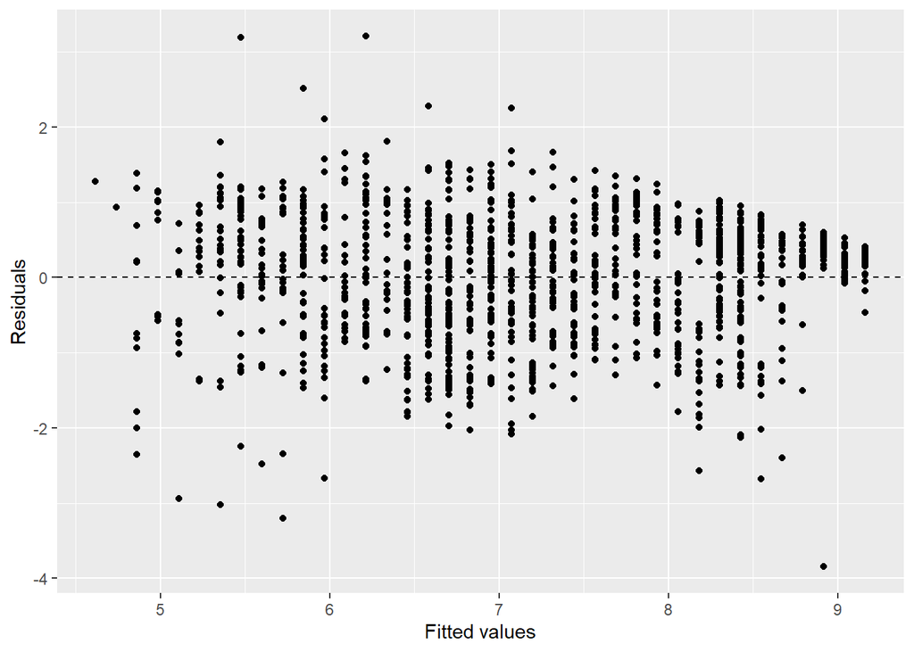

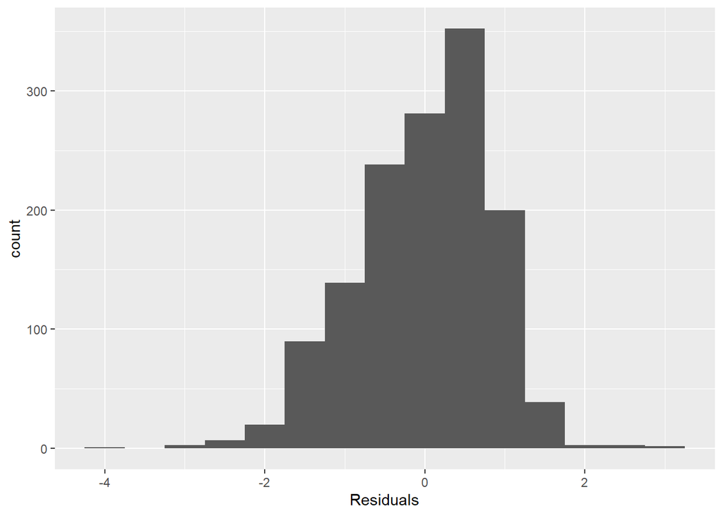

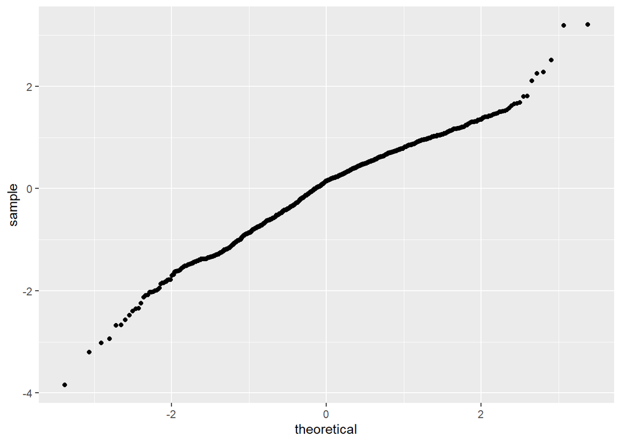

[figure not shown]